# R code: Correlations cannot distinguish interaction types in microbial networks

## Solve the model

The gLV model was solved with the lsoda function (from the deSolve package version 1.24). In the base case study, only one sample was ‘taken’ of the species abundances during equilibrium. Most gut microbiota studies are limited to only one or a few samples in time, presenting mere ‘snapshots’ of the intestinal ecosystem.

```r
# Make a list of n.simulations to store the time series
community.times <- n.simulations %>% vector( mode = "list", length = . )
# Make a list of n.simulations to store the samples taken during equilibrium
community.samples <- n.simulations %>% vector( mode = "list", length = . )

# Do for every simulation
for ( n in 1:length( community.times ) ) {
  # Make a list in the list of length N.samples.total
    community.times[[n]] <- n.samples.total %>% vector( mode = "list", length = . )
  # Make a matrix to collect the snapshot data
    community.samples[[n]] <- matrix( NA, nrow = n.species, ncol = n.samples.total )

  tryCatch( {

    # Do for every sample / host
    for ( o in 1:length( community.times[[ n ]] ) ) {

      # Solve the model with the chosen parameters
      community.time = lsoda( y = parms[[ n ]][[ o ]][ c( "yini" ) ] %>% unlist %>% as.numeric,
                              times = times,
                              func = gLV.model,
                              parms = parms[[ n ]][[ o ]] )

      # First column of community time dataset is time
      time = community.time[ ,1 ]
      # Second column till the last are the abundances per species
      community.time = community.time[ , 2:ncol( community.time ) ]
      # Transpose table
      community.time = t( community.time )
      # Use times as columnnames
      colnames( community.time ) = times

      # Change the data to a data frame
      abundances <- community.time %>% as.data.frame()
      # Get the name of the last column
      keep <- c( tend + 1 )
      # Keep only the abundances at the last time point (in the equilibrium)
      abundances <- abundances[ keep ] %>% simplify2array()

      # Store the abundances at the last time point in the list
      community.samples[[ n ]][ ,o ] <- abundances
    }
    # Do not stop the simulation because of an error or warning (but do not return any results)
  }, warning = function( e ){ return( NULL ) } )
  # Print the number of simulation, to see progress
  n %>% print()
}
```

Choose a community and plot it to see the timeseries.

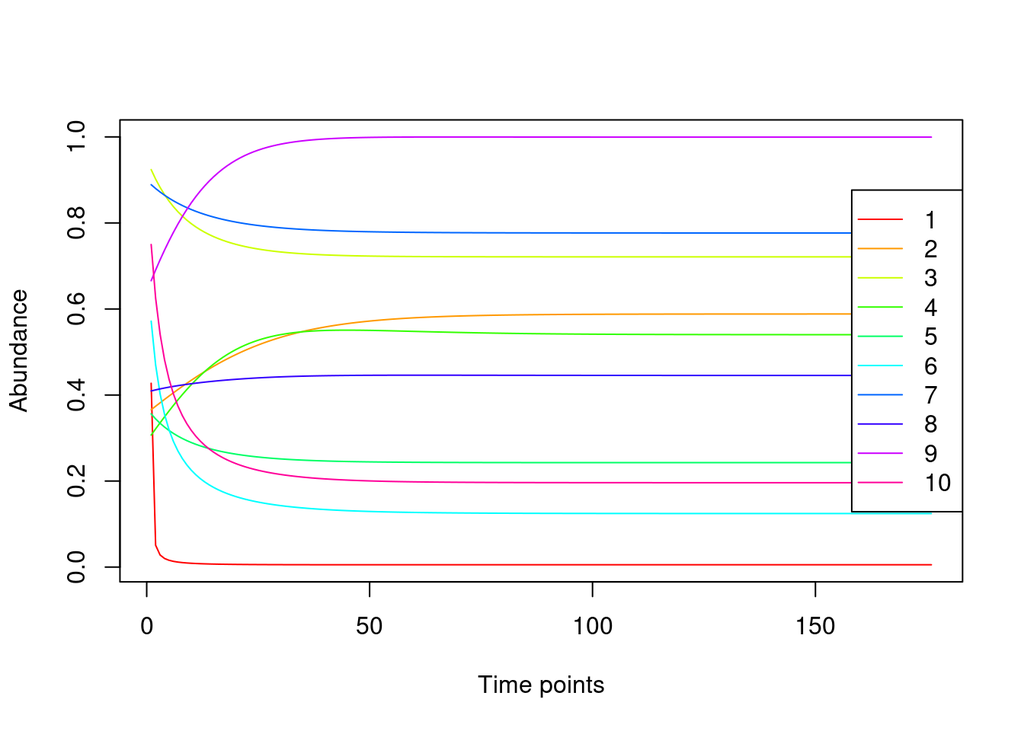

```r
# Show just one figure
par( mfrow = c( 1, 1 ) )
# Make a time plot (with the package seqtime)
community.time %>% tsplot( ., legend = T )
```

## Create the dataset

We added additive noise, drawn from a uniform distribution, to the abundances sampled in equilibrium to represent uncertainty in measurements (v).

```r
# Make a list of n.simulations
community.samples.withnoise <- n.simulations %>% vector( mode = "list", length = . )

# Do for every simulation
for (s in 1:length( community.samples.withnoise )) {
  # Create the level of noise
  measurement.noise <- community.samples[[ s ]] %>% length() %>%
    runif( ., -0.01, 0.01 ) %>%
    matrix( ., nrow = n.species, ncol = n.samples.total )
  # Add additive noise to the dataset
  community.samples.withnoise[[ s ]] <- community.samples[[ s ]] + measurement.noise

  # Create column- and rownames
  nms.of.samples = "Sample." %>% paste0( ., 1:n.samples.total )
  nms.of.species = parms[[ 1 ]][[ 1 ]]$A.matrix %>% colnames()
  # Name columns and rows
  colnames( community.samples.withnoise[[ s ]] ) = nms.of.samples
  rownames( community.samples.withnoise[[ s ]] ) = nms.of.species
  }
```

If species did not co-exist (when the abundance of a species fall below 0.001), we rejected the simulation.

```r
# Make a list of n.simulations
community.samples.survival <- n.simulations %>% vector( mode = "list", length = . )

for ( t in 1:length( community.samples.survival )) {
  # Transpose the dataset
  community.samples.transpose <- community.samples.withnoise[[ t ]] %>% t()
  # Change the values of species with an abundance below 0.001 to NA
  community.samples.survive <- ifelse( community.samples.transpose < 0.001, NA,
                                       community.samples.transpose )
  community.samples.survive <- community.samples.survive %>%  as.data.frame()
  # Remove columns with all NAs
  community.samples.survive <- Filter( function( x ) !all( is.na( x )), community.samples.survive )
  # Remove rows with at least one NA
  community.samples.survive <- community.samples.survive[ complete.cases( community.samples.survive ), ] %>% data.frame()

  # Number of species left
  species.left <- ncol( community.samples.survive )
  # Number of samples left
  samples.left <- nrow( community.samples.survive )

  survival <- c( species.left, samples.left ) %>% print()

  # Remove the simulation if not enough species and samples are left
  if ( species.left < n.species  | samples.left < n.samples ) {
    print( "not enough species survived" )
  } else {
    community.samples.survival[[t]]$data <- community.samples.survive %>% as.matrix()
  }
}
```

```
## [1]  10 399
## [1]  10 400
## [1]  10 400
## [1]  10 356
## [1]  10 400
## [1]  10 400
## [1]  10 400
## [1]  10 400
## [1]  10 400
## [1]  10 400
## [1]  10 218
## [1] "not enough species survived"
## [1]  10 400
## [1]  10 400
## [1]  10 400
```

[output cut: 39 more lines]

```r
# Check if there are simulations with not enough species or samples
removed.simulations.survival_error <- n.simulations %>% character()
for ( u in 1:length( community.samples.survival ) ) {
  # If errors occured, print number
  if( length( unlist( community.samples.survival[[u]] ) ) == 0 ) {
    # Store the numbers of the simulations with errors
    removed.simulations.survival_error[[u]] <- print( u )
  } else {
    removed.simulations.survival_error[[u]] <-print( NA )
  }
}
```

```
## [1] NA
## [1] NA
## [1] NA
## [1] NA
## [1] NA
## [1] NA
## [1] NA
## [1] NA
## [1] NA
## [1] NA
## [1] 11
## [1] NA
## [1] NA
## [1] NA
## [1] NA
```

[output cut: 35 more lines]

```r
# Remove empty list elements
community.samples.survival <- community.samples.survival %>% compact()
```

The samples that are removed in the previous step, also needs to be removed from the parms data.

```r
# Removed simulations after extinction of species
removed.simulations <- removed.simulations.survival_error %>% as.numeric()

# Keep only the parms that were not removed (== NA)
for ( v in 1:length( parms )) {
  if ( removed.simulations[[ v ]]  %>% is.na() ) {
    parms[[ v ]] <- parms[[ v ]]
  }   else {
    parms[[ v ]] <- list( NULL )
  }
}

# Remove the simulations where errors or not enough samples/species survived have occurred
parms <- Filter( function( x ) any( unlist( x ) != 0 ), parms )
```

We choose a higher number of samples than the preferred number we wanted to end up with. Therefore, randomly remove some of the samples to end up with the preferred number of samples in which all species coexist.

```r
# Make a list of n.simulations
data <- length( community.samples.survival ) %>% vector( mode = "list", length = . )

# Keep randomly the preferred number of samples
for ( w in 1:length( data )) {
  # Number of samples left
  samples.left <- nrow( community.samples.survival[[ w ]][[ "data" ]] )
  # Get the number of samples that need to be removed
  n.samples.to.remove = samples.left - n.samples
  # Transpose the data
  data.samples <- community.samples.survival[[ w ]][[ "data" ]] %>% t() %>% as.data.frame()
  # Choose the samples that will be removed
  samples.to.remove <- data.samples %>%
    sample( ., n.samples.to.remove )
  # Get the names of the samples to be removed
  names.samples.to.remove <- samples.to.remove %>% colnames()

  # Select the samples to keep
  data[[ w ]]$data <- data.samples %>%
    select( ., -one_of( names.samples.to.remove ) )
}

# Transpose the data
for ( x in 1:length( data ) ) {
  data[[ x ]]$data <- data[[ x ]][[ "data" ]] %>% t() %>% as.data.frame()
}

# Number of species in the first simulation
data[[ 1 ]][[ "data" ]] %>% ncol()
```

```
## [1] 10
```

```r
# Number of samples in the first simulation
data[[ 1 ]][[ "data" ]] %>% nrow()
```

```
## [1] 300
```

```r
# Make a list of n.simulations
names <- length( data ) %>% vector( mode = "list", length = . )

# Do for every sample / individual
for ( y in 1:length( data ) ) {
  names[[ y ]][[ "Samples" ]] <- rownames( data[[ y ]][[ "data" ]] )
  names[[ y ]][[ "Species" ]] <- colnames( data[[ y ]][[ "data" ]] )
}
```

## Calculate the partial correlations

First, we calculate the partial correlations.

```r
# Make a list of length  data
results.pcor <- length( data ) %>% vector( mode = "list", length = . )

for ( i in 1:length( data ) ) {
  # Calculate the covariance matrices from the abundance tables
  cx <- data[[ i ]][[ "data" ]] %>% as.data.frame() %>% cov()

  # Calculate the inverse of the covariance matrix
  dx <- cx %>% solve( ., sparse = TRUE,  tol = 1e-150 )
  # Calculate the partial correlation matrix
  pcor <- -cov2cor( dx )

  # Change the diagonal to 1 (instead of -1)
  diag( pcor ) <- 1

  # Store the results in the list
  results.pcor[[ i ]]$pcor <- pcor %>% as.matrix()
}
```

Hereafter we should keep only the significant partial correlations (corrected with the Benjamini Hochberg procedure). These significant correlation matrices are transformed to a matrix where, negative correlations are assigned a “-1”, positive correlations are assigned a “1” and if a correlation was not significant than the value “0” is implemented.

```r
# Do for all the pcors
pcor.pvalues.significant <- length( results.pcor ) %>% vector( mode = "list", length = . )

for ( i in 1:length( results.pcor )) {
  # Number of samples
  pcor.n <- dim( data[[ i ]][[ "data" ]] )[ 1 ]
  pcor.gp <- dim( data[[ i ]][[ "data" ]] )[ 2 ]-2

  # Do the statistics
  pcor.statistic <- results.pcor[[ i ]][[ "pcor" ]] *
    sqrt(( pcor.n-2-pcor.gp ) / ( 1-results.pcor[[ i ]][[ "pcor" ]]^2 ))
  # Get the p values
  pcor.pvalues <- 2 * pnorm( -abs( pcor.statistic ))

  # Adjust the p-values with Benjamini-Hochberg procedure
  pcor.pvalues.adjusted <- array( NA, dim = dim( pcor.pvalues ))
  names <- colnames( pcor.pvalues )
  colnames( pcor.pvalues.adjusted ) <- names
  rownames( pcor.pvalues.adjusted ) <- names
  for ( j in 1:dim( pcor.pvalues )[ 1 ] )
    pcor.pvalues.adjusted[ j, ] <- p.adjust( pcor.pvalues[ j, ], method = "BH" )

  # Keep the significant results
  pcor.pvalues.sign <- pcor.pvalues.adjusted < 0.05
  # Change true (significant correlations) in 1 and false (non-significant correlations) to 0
  pcor.pvalues.sign <- 1 * pcor.pvalues.sign

  # Change the values to negative (-1), no (0) and positive interaction (1) matrices
  pcor.pvalues.sign <- ifelse( pcor.pvalues.sign == 0, 0,
                               ifelse( results.pcor[[ i ]][[ "pcor" ]] >= 0, 1, -1 ) )

  # Remove the diagonal
  diag( pcor.pvalues.sign ) <- NA

  # Store in the results
  pcor.pvalues.significant[[ i ]] <- pcor.pvalues.sign
}
```

## Calculate precision, recall and the F1-scores

These measures are used to compare the original interaction matrix from the model with the inferred significant partial correlations.

```r
# Make a list
A.matrix.analysis <- list()

# Subtract all the interaction matrices
for ( i in 1:length( parms )) {
  # Make a list per simulation
 A.matrix.analysis[[ i ]] <- length( parms[[ i ]] ) %>% vector( mode = "list", length = . )
  for ( j in 1:length( parms[[ i ]] ) ) {
    # Here we use the A matrix without noise
   A.matrix.analysis[[ i ]]<- parms[[ i ]][[ j ]][ c( "A.matrix" ) ]
  }
}

# Flatten the list of lists
A.matrix.analysis <- A.matrix.analysis %>% flatten()
```

After selecting the variables of interest, the interaction matrix is transformed in a similar way as the significant partial correlation matrix, with the -1, 0 and 1 for respectively negative, none and positive interactions.

```r
# Do for all the A-matrices
A.matrix.round <- length( A.matrix.analysis ) %>% vector( mode = "list", length = . )

for ( i in 1:length( A.matrix.round ) ) {
  # change the A-matrices to negative (-1), no (0) and positive interaction (1) matrices
 A.matrix.analysis.01 <- ifelse( A.matrix.analysis[[ i ]] == 0, 0,
                                  ifelse( A.matrix.analysis[[ i ]] >= 0, 1, -1 ))

  # Remove the diagonal, because that has nothing to do with interactions
  diag( A.matrix.analysis.01 ) <- NA

  # Store in the results
 A.matrix.round[[ i ]] <- A.matrix.analysis.01
}
```

Calculate the confusion matrix.

```r
# Make a new list
confusion.matrix <- length( A.matrix.round ) %>% vector( mode = "list", length = . )

# Do for every simulation
for ( i in 1:length( A.matrix.round )) {

  # Make an actual and predicted matrix
  actual <- A.matrix.round[[ i ]]
  predicted <- pcor.pvalues.significant[[ i ]]

  # Change the upper half of the predicted matrix to NA (because it is symmetric)
  predicted[ upper.tri( predicted ) ] <- NA

  # Make a empty confusion matrix to store the results
  # Actual are rows, predicted are columns
  results <- matrix( 0, 3, 3 )
  colnames( results ) <- c( "-1", "0", "1" )
  rownames( results ) <- c( "-1", "0", "1" )

  # Go through every row and column
  for ( r in 1:nrow( predicted )) {
    for ( c in 1:ncol( predicted )) {

      # If the value is NA, than do nothing
      if( is.na( predicted[ r, c ] )) {
        results[ 1, 1 ] = results[ 1, 1 ] + 0

        # If cor is 0 and interactions are both 0
      } else if ( predicted[ r, c ] == 0 & ( actual[ r, c ] == 0 & actual[ c, r ] == 0 ) ) {
        # Than a true negative
        results[ 2, 2 ] = results[ 2, 2 ] + 1
        # If cor is 0 and one of the interactions is 1
      } else if ( predicted[ r, c ] == 0 & ( actual[ r, c ] == 1 | actual[ c, r ] == 1 ) ) {
        # Than a false negative
        results[ 3, 2 ] = results[ 3, 2 ] + 1
        # If cor is 0 and one of the interactions is -1
      } else if ( predicted[ r, c ] == 0 & ( actual[ r, c ] == -1 | actual[ c, r ] == -1 )) {
        # Than a false negative
        results[ 1, 2 ] = results[ 1, 2 ] + 1

        # If cor is 1 and one of the interactions is 1
      } else if ( predicted[ r, c ] == 1 & ( actual[ r, c ] == 1 | actual[ c, r ] == 1 )) {
        # Than a true positive
        results[ 3, 3 ] = results[ 3, 3 ] + 1
        # If cor is 1 and interactions are both 0
      } else if ( predicted[ r, c ] == 1 & ( actual[ r, c ] == 0 & actual[ c, r ] == 0 )) {
        # Than a false positive
        results[ 2, 3 ] = results[ 2, 3 ] + 1
        # If cor is 1 and interactions are both -1
      } else if ( predicted[ r, c ] == 1 & ( actual[ r, c ] == -1 & actual[ c, r ] == -1 )) {
        # Than a false positive (wrong sign)
        results[1, 3] = results[1, 3] + 1

        # If cor is -1 and one of the interactions is -1
      } else if ( predicted[ r, c ] == -1 & ( actual[ r, c ] == -1 | actual[ c, r ] == -1 )) {
        # Than a true positive
        results[ 1, 1 ] = results[ 1, 1 ] + 1
        # If cor is -1 and interactions are both 0
      } else if ( predicted[ r, c ] == -1 & ( actual[ r, c ] == 0 & actual[ c, r ] == 0 )) {
        # Than a false positive
        results[ 2, 1 ] = results[ 2, 1 ] + 1
        # If cor is -1 and interactions are both 1
      } else if( predicted[ r, c ] == -1 & ( actual[ r, c ] == 1 & actual[ c, r ] == 1 )) {
        # Than a false positive (wrong sign)
        results[ 3, 1 ] = results[ 3, 1 ] + 1
      }
      # Store the results in the list
      confusion.matrix[[ i ]] <- results
    }
  }
}
```

Calculate the precision, recall and F1-scores

```r
# Make a list to store the results
F1.score <- length( confusion.matrix ) %>% vector( mode = "list", length = . )

# Calculate F1 score with paying attention to the sign
for ( i in 1:length( confusion.matrix )) {
  confusion <- confusion.matrix[[ i ]]

  # Calculate the precision
  precision = ( confusion[ 1, 1 ] + confusion[ 3, 3 ] ) / (( confusion[ 1, 1 ] + confusion[ 3, 3 ] ) +
                                                          ( confusion[ 2, 1 ] + confusion[ 3, 1 ] + confusion[ 1, 3 ] + confusion[ 2, 3 ] ))
  F1.score[[i]]$precision <- precision

  # Calculate the recall
  recall = ( confusion[ 1, 1 ] + confusion[ 3, 3 ] ) / (( confusion[ 1, 1 ] + confusion[ 3, 3 ] ) + ( confusion[ 1, 2 ] + confusion[ 3, 2 ] ))
  F1.score[[i]]$recall <- recall

  # Calculate the F1-scores
  F1score <- 2 * (( precision * recall ) / ( precision + recall ))
  F1.score[[ i ]]$F1score <- F1score
}
```

Plot the results

```r
# Make an empty dataframe
F1.score.data <- matrix( 0, nrow = length( F1.score ), ncol = 3 )

# Do for every simulation
# Make a dataframe with the results
for ( i in 1:length( F1.score ) ) {
  F1.score.data[ i, 1 ] <- F1.score[[ i ]][[ "precision" ]]
  F1.score.data[ i, 2 ] <- F1.score[[ i ]][[ "recall" ]]
  F1.score.data[ i, 3 ] <- F1.score[[ i ]][[ "F1score" ]]
}

# Change the NAs in the data to 0
F1.score.data <- F1.score.data %>% replace( ., is.na( F1.score.data ), 0 )
# Name the columns
colnames( F1.score.data ) <- c( "Precision", " Recall", " F1.score" )

F1.score.data.2 <- F1.score.data %>% melt( ., id.vars = "F1.score" )
str( F1.score.data.2 )
```

```
## 'data.frame':    138 obs. of  3 variables:
##  $ Var1 : int  1 2 3 4 5 6 7 8 9 10 ...
##  $ Var2 : Factor w/ 3 levels "Precision"," Recall",..: 1 1 1 1 1 1 1 1 1 1 ...
##  $ value: num  0.8 1 1 1 1 ...
```

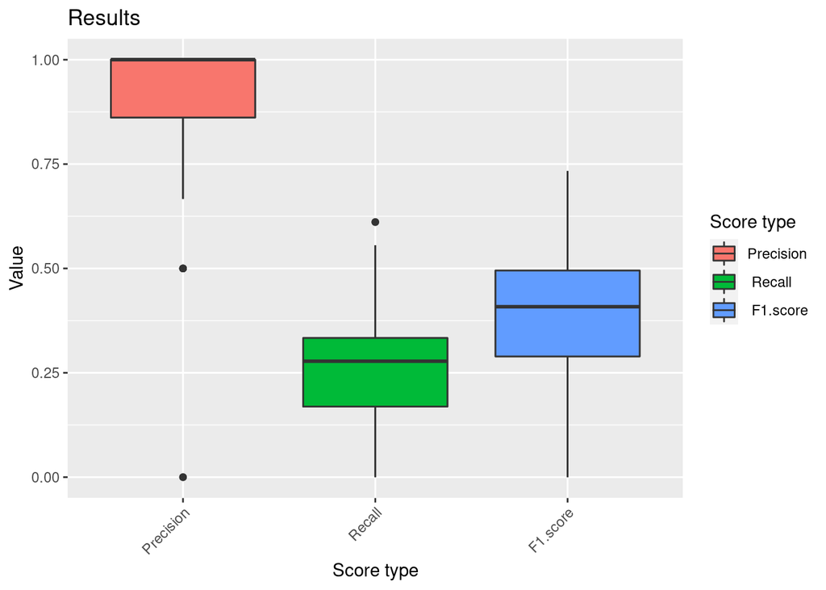

```r
F1.score.data.2$value <- as.numeric( as.character( F1.score.data.2$value ))

# Make the boxplots
boxplot <- ggplot( data = F1.score.data.2,
                   mapping = aes( x = Var2, y = value )) +
  geom_boxplot() +
  # Name the labels
  labs( x = "Score type", y = "Value" ) +
  # Text over an angle
  theme( axis.text.x = element_text( angle = 45, hjust = 1 ))  +
  # Color the boxes
  geom_boxplot(
    aes( fill = Var2 ),
    position = position_dodge( 0.9 )) +
  ggtitle( paste( "Results", sep = ",", collapse = NULL))  +
  guides( fill = guide_legend( title = "Score type" )) +
  scale_y_continuous( limits = c( 0, 1 ))
# Plot the boxplots
boxplot
```